# 13 Model Diagnositc

kwon

2018년 6월 27일

# 1. Model Assumptions

Assumptions of Linear Regression  
Linearity: the response can be written as a linear combinations of the predictors.  
Independence: the errors are independent.  
Normality: the distribution of the errors should follow a normal distribution.  
Equal Variance: the error variance is the same at any set of predictor values.

# 2. Checking Assumptions

$$Model 1: Y = 3+5x +\epsilon, \epsilon \sim \mathcal{N(0,1)}$$
$$Model 2: Y = 3+5x +\epsilon, \epsilon \sim \mathcal{N(0,x^2)}$$
$$Model 3: Y = 3+5x^2 +\epsilon, \epsilon \sim \mathcal{N(0,25)}$$

```r
sim_1 = function(sample_size = 500){
  x= runif(n=sample_size)*5
  y = 3+5*x + rnorm(n=sample_size, mean=0, sd=1)
  data.frame(x,y)
}

sim_2 = function(sample_size = 500){
  x = runif(n=sample_size)*5
  y = 3+5*x + rnorm(n=sample_size, mean=0, sd=x)
  data.frame(x,y)
}

sim_3 = function(sample_size =500){
  x = runif(n=sample_size)*5
  y = 3 + 5*x^2 +rnorm(n=sample_size, mean=0, sd=5)
  data.frame(x,y)
}
```

## 2.1 Fitted versus Residual Plots

Useful for checking the linearity and constant variance

```r
set.seed(42)
sim_data_1 = sim_1()
head(sim_data_1)
```

```
##          x         y
## 1 4.574030 24.773995
## 2 4.685377 26.475936
## 3 1.430698  8.954993
## 4 4.152238 23.951210
## 5 3.208728 20.341344
## 6 2.595480 14.943525
```

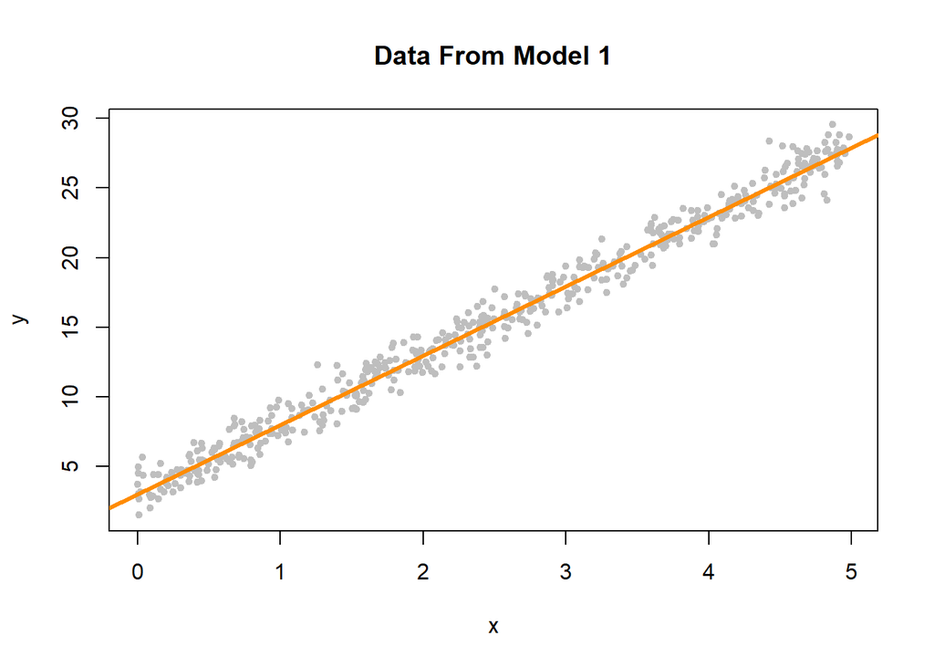

```r
plot(y~x, data=sim_data_1, col="grey", pch=20, main= "Data From Model 1")
fit_1 = lm(y~x, data=sim_data_1)
abline(fit_1, col= "darkorange", lwd=3)
```

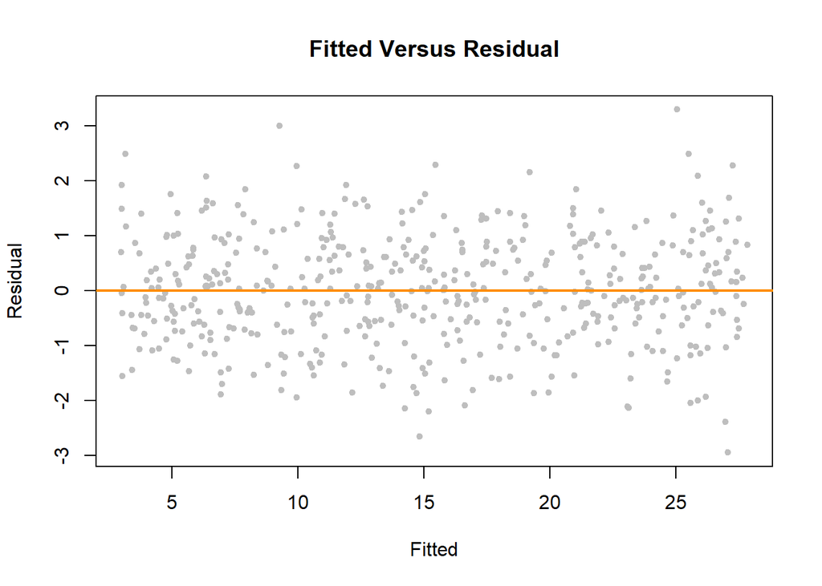

```r
plot(fitted(fit_1), resid(fit_1), pch=20, col="grey", main = "Fitted Versus Residual", xlab = "Fitted", ylab="Residual")
abline(h =0, col="darkorange", lwd=2)
```

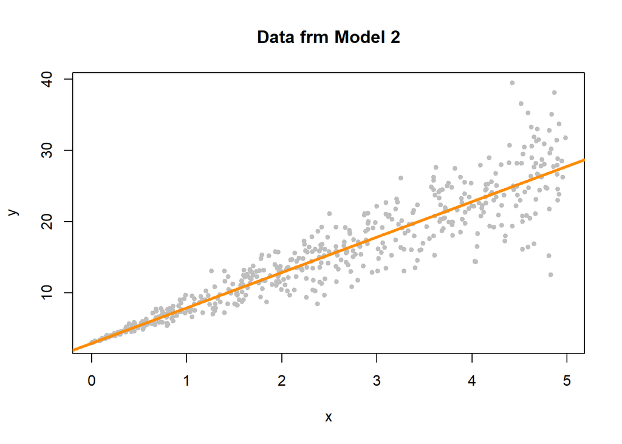

```r
set.seed(42)
sim_data_2 = sim_2()
fit_2 = lm(y~x, data = sim_data_2)
plot(y ~ x, data= sim_data_2, col="grey", pch=20, main = "Data frm Model 2")
abline(fit_2, col="darkorange", lwd=3)
```

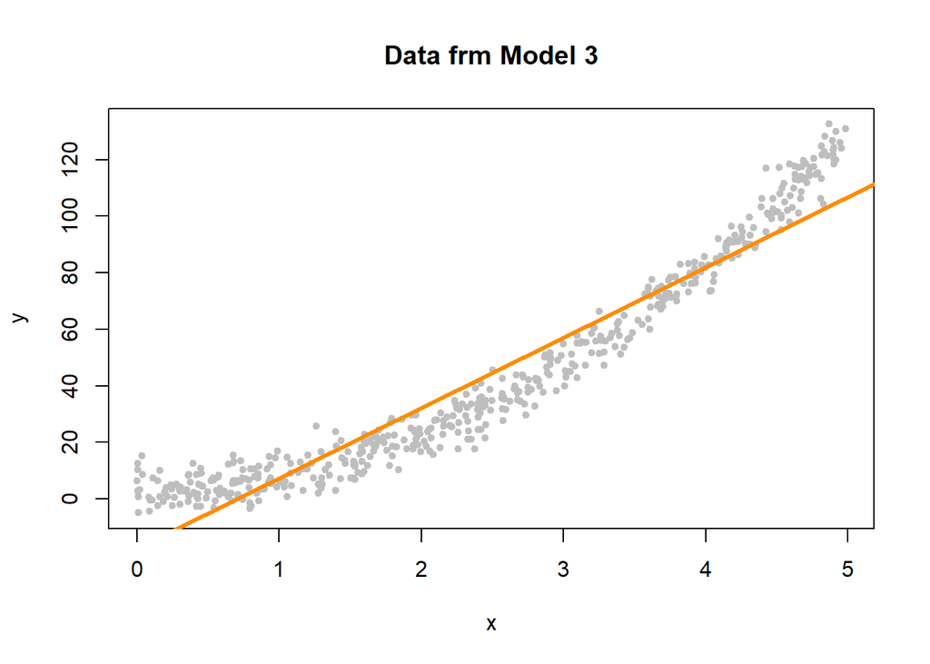

```r
set.seed(42)
sim_data_3 = sim_3()
fit_3 = lm(y~x, data = sim_data_3)
plot(y ~ x, data= sim_data_3, col="grey", pch=20, main = "Data frm Model 3")
abline(fit_3, col="darkorange", lwd=3)
```

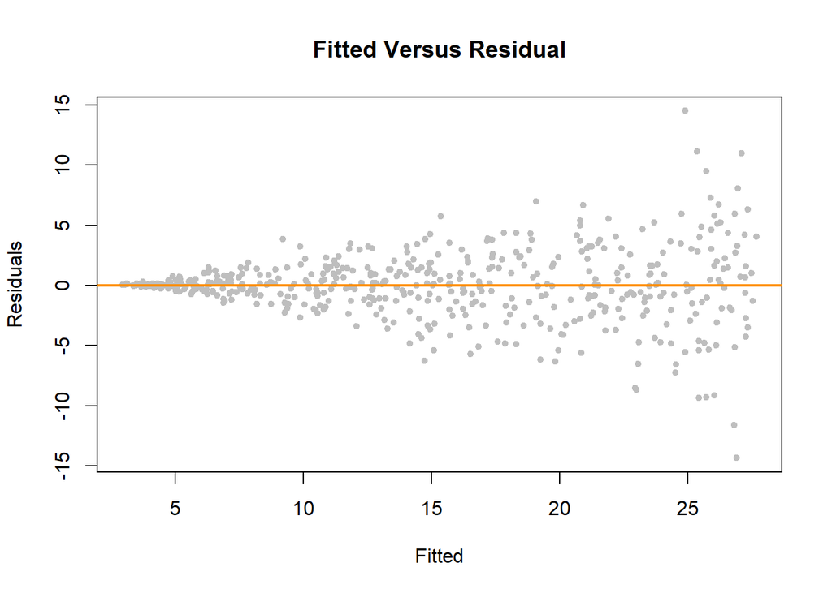

```r
plot(fitted(fit_2), resid(fit_2), col="grey", pch=20, xlab ="Fitted", ylab="Residuals", main = "Fitted Versus Residual")
abline(h=0, col="darkorange", lwd=2)
```

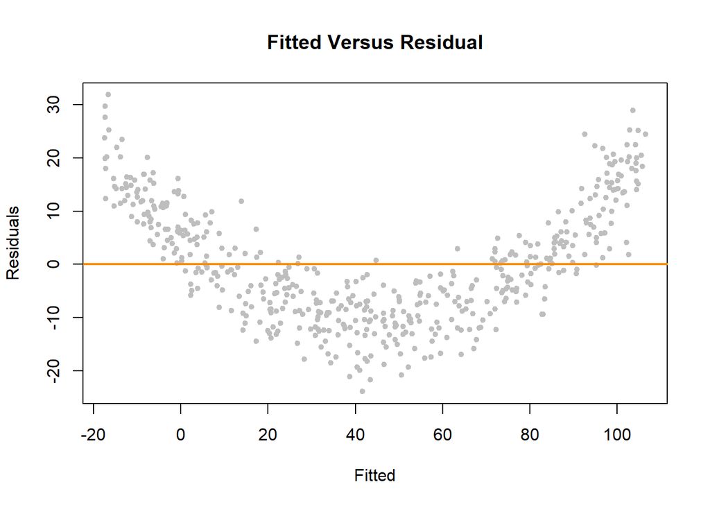

```r
plot(fitted(fit_3), resid(fit_3), col="grey", pch=20, xlab ="Fitted", ylab="Residuals", main = "Fitted Versus Residual")
abline(h=0, col="darkorange", lwd=2)
```

Model 2: Constant variance assumption is violated Model 3: Linearity assumption is violated

## 2.2 Breusch-Pagan Test

H0: Homoscedasticity. The errors have constant variance about the true model.  
H1: Heteroscedasticity. The errors have non-constant variance about the true model.

```r
library(lmtest)
bptest(fit_1)
```

```
##
##  studentized Breusch-Pagan test
##
## data:  fit_1
## BP = 1.0234, df = 1, p-value = 0.3117
```

```r
bptest(fit_2)
```

```
##
##  studentized Breusch-Pagan test
##
## data:  fit_2
## BP = 76.693, df = 1, p-value < 2.2e-16
```

```r
bptest(fit_3)
```

```
##
##  studentized Breusch-Pagan test
##
## data:  fit_3
## BP = 0.33466, df = 1, p-value = 0.5629
```

## 2.3 Historgram

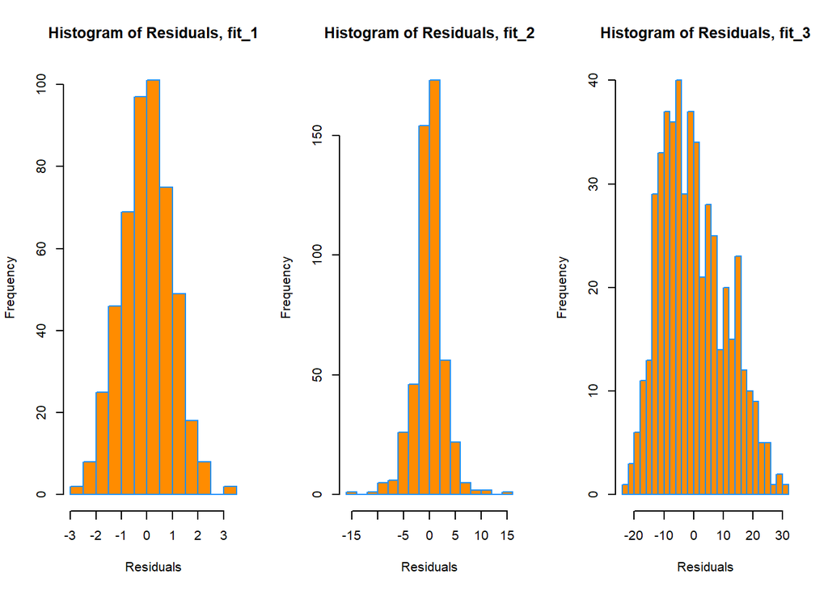

```r
par(mfrow = c(1, 3))
hist(resid(fit_1),
     xlab   = "Residuals",
     main   = "Histogram of Residuals, fit_1",
     col    = "darkorange",
     border = "dodgerblue",
     breaks = 20)
hist(resid(fit_2),
     xlab   = "Residuals",
     main   = "Histogram of Residuals, fit_2",
     col    = "darkorange",
     border = "dodgerblue",
     breaks = 20)
hist(resid(fit_3),
     xlab   = "Residuals",
     main   = "Histogram of Residuals, fit_3",
     col    = "darkorange",
     border = "dodgerblue",
     breaks = 20)
```

## 2.4 Q-Q Plots Normal Quantile-Quantile plot

```r
# qqnorm() plots the points
qqnorm(resid(fit_1), main = "Normal Q-Q Plot, fit_1", col = "darkgrey")
# qqline adds the necessary line
qqline(resid(fit_1), col = "dodgerblue", lwd = 2)
```

[output not shown]

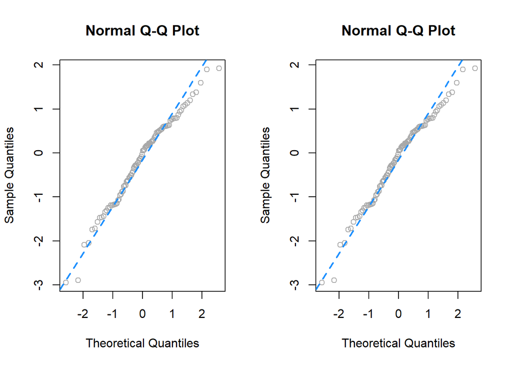

```r
qq_plot = function(e){
  n = length(e)
  normal_quantiles = qnorm(((1:n-0.5)/n))

  # plot theoretical versus observed quantiles
  plot(normal_quantiles, sort(e),
       xlab = c("Theoretical Quantiles"),
       ylab = c("Sample Quantiles"),
       col = "darkgrey")
  title("Normal Q-Q Plot")

  # calculate line through the first and third quantiles
  slope = (quantile(e, 0.75) - quantile(e, 0.25)) / (qnorm(0.75)-qnorm(0.25))
  intercept = quantile(e, 0.25) - slope*qnorm(0.25)

  # add to existing plot
  abline(intercept, slope, lty=2, lwd=2, col="dodgerblue")
}

set.seed(420)
x = rnorm(100, mean = 0 , sd = 1)
par(mfrow = c(1, 2))
qqnorm(x, col = "darkgrey")
qqline(x, lty = 2, lwd = 2, col = "dodgerblue")
qq_plot(x)
```

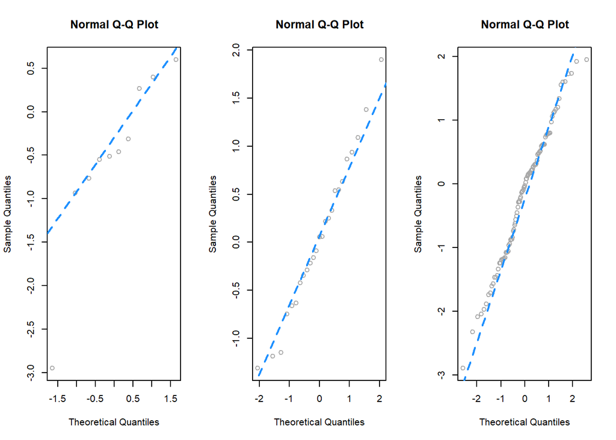

```r
par(mfrow = c(1, 3))
set.seed(420)
qq_plot(rnorm(10))
qq_plot(rnorm(25))
qq_plot(rnorm(100))
```

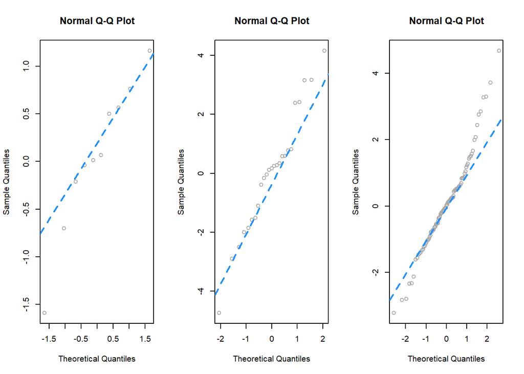

```r
par(mfrow = c(1, 3))
set.seed(420)
qq_plot(rt(10, df = 4))
qq_plot(rt(25, df = 4))
qq_plot(rt(100, df = 4))
```

```r
qqnorm(resid(fit_1), main = "Normal Q-Q Plot, fit_1", col = "darkgrey")
qqline(resid(fit_1), col = "dodgerblue", lwd = 2)
```

[output not shown]

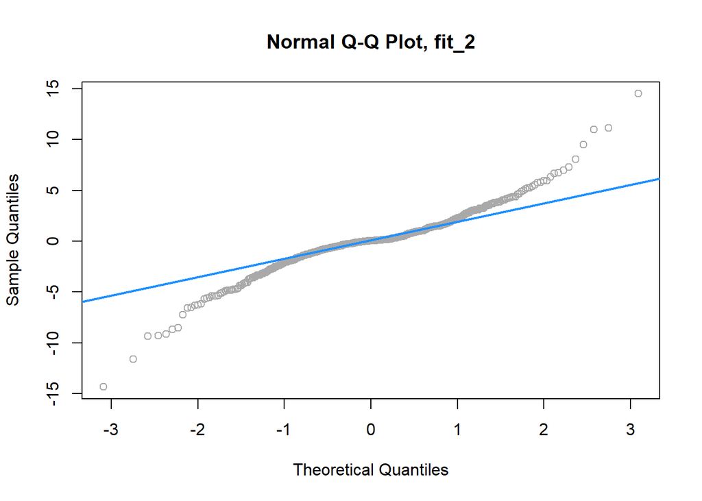

```r
qqnorm(resid(fit_2), main = "Normal Q-Q Plot, fit_2", col = "darkgrey")
qqline(resid(fit_2), col = "dodgerblue", lwd = 2)
```

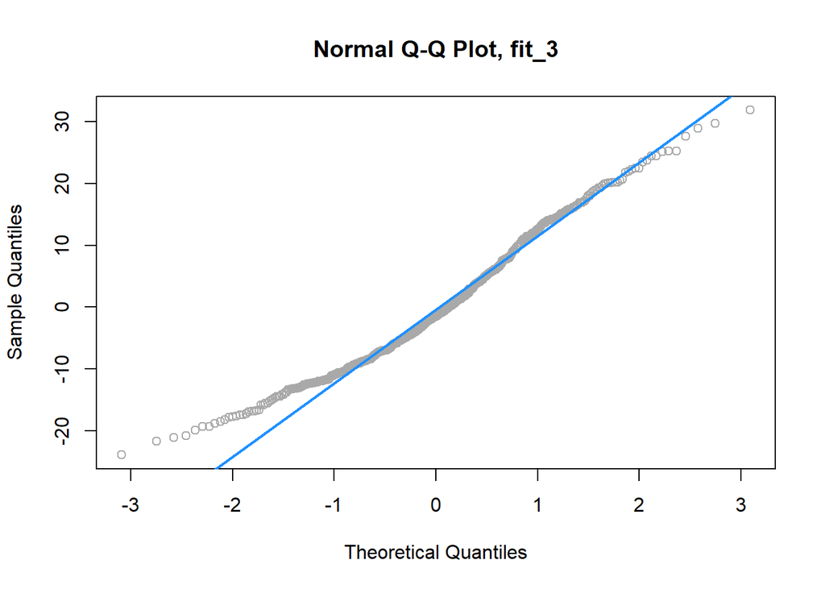

```r
qqnorm(resid(fit_3), main = "Normal Q-Q Plot, fit_3", col = "darkgrey")
qqline(resid(fit_3), col = "dodgerblue", lwd = 2)
```

## 2.5 Shapiro-Wilk Test

```r
set.seed(42)
shapiro.test(rnorm(25))
```

```
##
##  Shapiro-Wilk normality test
##
## data:  rnorm(25)
## W = 0.9499, p-value = 0.2495
```

```r
shapiro.test(rexp(25))
```

```
##
##  Shapiro-Wilk normality test
##
## data:  rexp(25)
## W = 0.71164, p-value = 1.05e-05
```

```r
shapiro.test(resid(fit_1))
```

```
##
##  Shapiro-Wilk normality test
##
## data:  resid(fit_1)
## W = 0.99858, p-value = 0.9622
```

```r
shapiro.test(resid(fit_2))
```

```
##
##  Shapiro-Wilk normality test
##
## data:  resid(fit_2)
## W = 0.93697, p-value = 1.056e-13
```

```r
shapiro.test(resid(fit_3))
```

```
##
##  Shapiro-Wilk normality test
##
## data:  resid(fit_3)
## W = 0.97643, p-value = 3.231e-07
```

# 3. Unsusual Observations

```r
par(mforw= c(1,3))
```

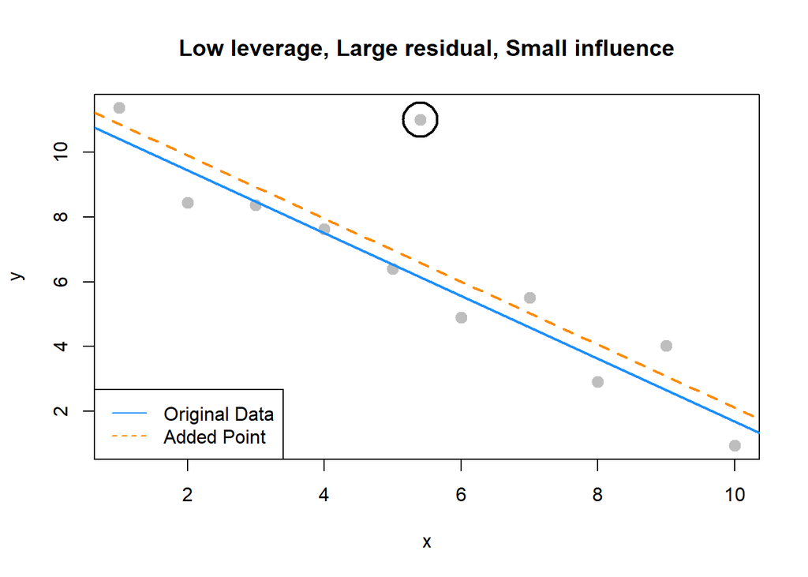

```r
set.seed(42)
ex_data = data.frame(x=1:10, y = 10:1 + rnorm(n=10))
ex_model = lm(y~x, data= ex_data)

# Low leverage, large residual, small influence
point_1 = c(5.4, 11)
ex_data_1 = rbind(ex_data, point_1)
model_1 = lm(y ~ x, data = ex_data_1)
plot(y~x, data= ex_data_1, cex= 2, pch = 20, col="grey", main="Low leverage, Large residual, Small influence")
points(x=point_1[1], y=point_1[2], pch=1, cex=4, col="black", lwd=2)
abline(ex_model, col="dodgerblue", lwd=2)
abline(model_1, lty = 2, col="darkorange", lwd=2)
legend("bottomleft", c("Original Data", "Added Point"), lty=c(1,2), col=c("dodgerblue", "darkorange"))
```

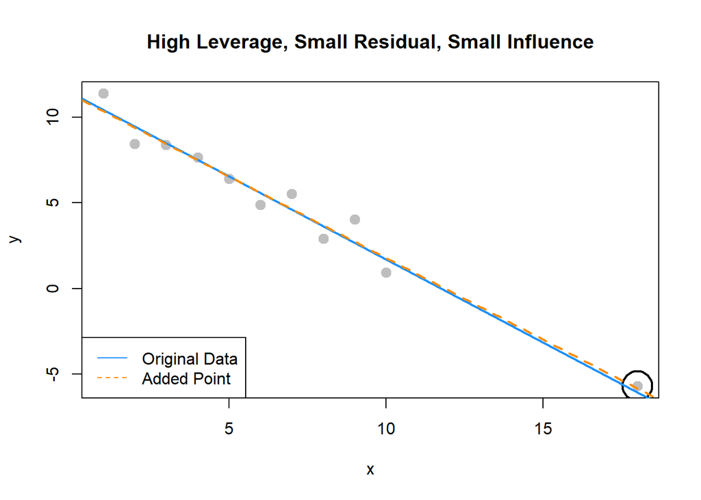

```r
# high leverage, small residual, small influence
point_2 = c(18, -5.7)
ex_data_2 = rbind(ex_data, point_2)
model_2 = lm(y ~ x, data = ex_data_2)
plot(y ~ x, data = ex_data_2, cex = 2, pch = 20, col = "grey",
     main = "High Leverage, Small Residual, Small Influence")
points(x = point_2[1], y = point_2[2], pch = 1, cex = 4, col = "black", lwd = 2)
abline(ex_model, col = "dodgerblue", lwd = 2)
abline(model_2, lty = 2, col = "darkorange", lwd = 2)
legend("bottomleft", c("Original Data", "Added Point"),
       lty = c(1, 2), col = c("dodgerblue", "darkorange"))
```

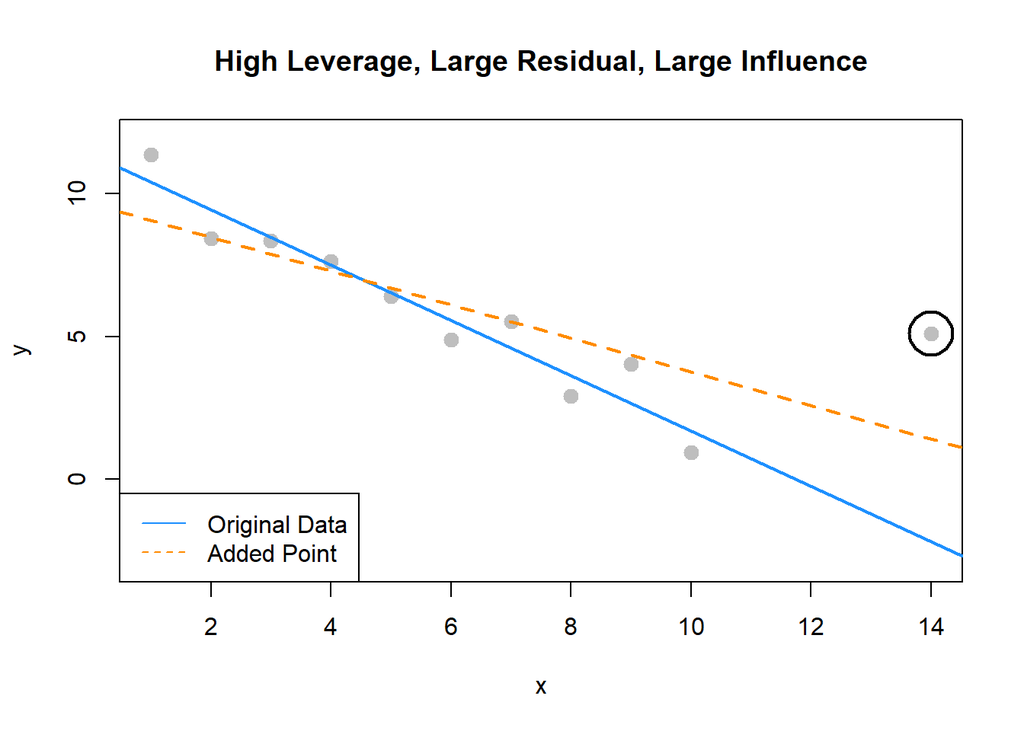

```r
# high leverage, large residual, large influence
point_3 = c(14, 5.1)
ex_data_3 = rbind(ex_data, point_3)
model_3 = lm(y ~ x, data = ex_data_3)
plot(y ~ x, data = ex_data_3, cex = 2, pch = 20, col = "grey", ylim = c(-3, 12),
     main = "High Leverage, Large Residual, Large Influence")
points(x = point_3[1], y = point_3[2], pch = 1, cex = 4, col = "black", lwd = 2)
abline(ex_model, col = "dodgerblue", lwd = 2)
abline(model_3, lty = 2, col = "darkorange", lwd = 2)
legend("bottomleft", c("Original Data", "Added Point"),
       lty = c(1, 2), col = c("dodgerblue", "darkorange"))
```

```r
coef(ex_model)[2]
```

```
##          x
## -0.9696033
```

```r
coef(model_1)[2]
```

```
##          x
## -0.9749534
```

```r
coef(model_2)[2]
```

```
##          x
## -0.9507397
```

```r
coef(model_3)[2]
```

```
##          x
## -0.5892241
```

## 3.1 Leverage

A data point with high leverage, is a data point that could have large influence when fitting the model.

$$\hat\beta = (X^TX)^{-1}X^Ty$$
$$\hat{y} = \hat\beta = X(X^TX)^{-1}X^Ty$$
$$H = X(X^TX)^{-1}X^T$$
Hat matrix is used to project onto the subspace spanned by the columns of X.
$$\hat y = Hy$$
The diagnoal elements of this matrix are called leverages
$$H_{ii} = h_{i}$$

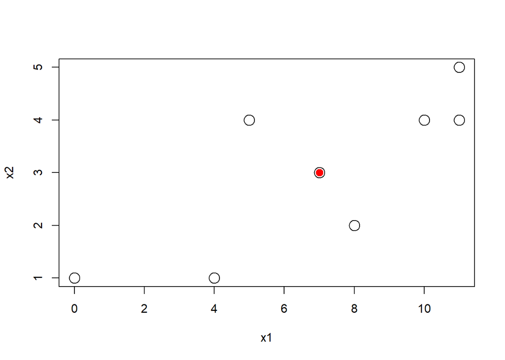

```r
lev_ex = data.frame(
  x1 = c(0, 11, 11, 7, 4, 10, 5, 8),
  x2 = c(1, 5, 4, 3, 1, 4, 4, 2),
  y = c(11, 15, 13, 14, 0, 19, 16, 8)
)
plot(x2 ~ x1, data=lev_ex, cex=2)
points(7,3, pch=20, col ="red", cex=2)
```

```r
X = cbind(rep(1,8), lev_ex$x1, lev_ex$x2)
H = X %*% solve(t(X)%*%X) %*% t(X)
diag(H)
```

```
## [1] 0.6000 0.3750 0.2875 0.1250 0.4000 0.2125 0.5875 0.4125
```

```r
sum(diag(H))
```

```
## [1] 3
```

```r
lev_fit = lm(y~., data = lev_ex)
hatvalues(lev_fit)
```

```
##      1      2      3      4      5      6      7      8
## 0.6000 0.3750 0.2875 0.1250 0.4000 0.2125 0.5875 0.4125
```

```r
coef(lev_fit)
```

```
## (Intercept)          x1          x2
##         3.7        -0.7         4.4
```

```r
lev_ex[which.max(hatvalues(lev_fit)),]
```

```
##   x1 x2  y
## 1  0  1 11
```

```r
lev_ex_1 = lev_ex
lev_ex_1$y[1] =20
lm(y~., data=lev_ex_1)
```

```
##
## Call:
## lm(formula = y ~ ., data = lev_ex_1)
##
## Coefficients:
## (Intercept)           x1           x2
##       8.875       -1.375        4.625
```

```r
lev_ex[which.min(hatvalues(lev_fit)),]
```

```
##   x1 x2  y
## 4  7  3 14
```

```r
lev_ex_2 = lev_ex
lev_ex_2$y[4] = 30
lm(y ~ ., data = lev_ex_2)
```

```
##
## Call:
## lm(formula = y ~ ., data = lev_ex_2)
##
## Coefficients:
## (Intercept)           x1           x2
##         5.7         -0.7          4.4
```

```r
hatvalues(model_1) > 2 * mean(hatvalues(model_1))
```

```
##     1     2     3     4     5     6     7     8     9    10    11
## FALSE FALSE FALSE FALSE FALSE FALSE FALSE FALSE FALSE FALSE FALSE
```

```r
hatvalues(model_2) > 2 * mean(hatvalues(model_2))
```

```
##     1     2     3     4     5     6     7     8     9    10    11
## FALSE FALSE FALSE FALSE FALSE FALSE FALSE FALSE FALSE FALSE  TRUE
```

```r
hatvalues(model_3) > 2 * mean(hatvalues(model_3))
```

```
##     1     2     3     4     5     6     7     8     9    10    11
## FALSE FALSE FALSE FALSE FALSE FALSE FALSE FALSE FALSE FALSE  TRUE
```

## 3.2 Outliers

Outliers are points which do not fit the model well.
$$e= y-\hat y = Iy - Hy = (I-H)y$$

$$Var(e_{i}) = (1-h_i)\sigma^2)$$
$$SE[e_i] = s_e\sqrt{(1-h_i)}$$
Standardized residual when n is large
$$r_i = \frac{e_i}{s_e\sqrt{1-h_i}} \sim N(\mu = 0, \sigma^2 = 1)$$

```r
resid(model_1)
```

```
##          1          2          3          4          5          6
##  0.4949887 -1.4657145 -0.5629345 -0.3182468 -0.5718877 -1.1073271
##          7          8          9         10         11
##  0.4852728 -1.1459548  0.9420814 -1.1641029  4.4138254
```

```r
rstandard(model_1)
```

```
##          1          2          3          4          5          6
##  0.3464701 -0.9585470 -0.3517802 -0.1933575 -0.3428264 -0.6638841
##          7          8          9         10         11
##  0.2949482 -0.7165857  0.6167268 -0.8160389  2.6418234
```

```r
rstandard(model_1)[abs(rstandard(model_1))>2]
```

```
##       11
## 2.641823
```

```r
rstandard(model_2)[abs(rstandard(model_2))>2]
```

```
## named numeric(0)
```

```r
rstandard(model_3)[abs(rstandard(model_3))>2]
```

```
##       11
## 2.704534
```

First plot has 11th point, the added point, with a large standardized residual. Second plot does not have one.  
The added point in plots two and three were both high leverage, but now only the point in plot three ahs a large residual.

## 3.3 Influence

Some outliers only change the regression a small amount(plot one) and some outliers have a large effect on the regression(plot three). Points with high leverage and large residual, we will call influential.
A common measure of influence is **Cook’s Distance**,
$$D_i = \frac{1}{p}r_i^2 \frac{h_i}{1-h_i}$$

Plot One: low leverage, large residual.  
Plot Two: high leverage, small residual.  
Plot Three: high leverage, large residual.

```r
n = length(resid(model_1))
cooks.distance(model_1)[11] > 4 /n
```

```
##    11
## FALSE
```

```r
cooks.distance(model_2)[11] > 4 /n
```

```
##    11
## FALSE
```

```r
cooks.distance(model_3)[11] > 4 /n
```

```
##   11
## TRUE
```

# 4. Data Analysis Examples

# 13 Model Diagnositc

kwon

2018년 6월 27일

# 1. Model Assumptions

Assumptions of Linear Regression  
Linearity: the response can be written as a linear combinations of the predictors.  
Independence: the errors are independent.  
Normality: the distribution of the errors should follow a normal distribution.  
Equal Variance: the error variance is the same at any set of predictor values.

# 2. Checking Assumptions

$$Model 1: Y = 3+5x +\epsilon, \epsilon \sim \mathcal{N(0,1)}$$
$$Model 2: Y = 3+5x +\epsilon, \epsilon \sim \mathcal{N(0,x^2)}$$
$$Model 3: Y = 3+5x^2 +\epsilon, \epsilon \sim \mathcal{N(0,25)}$$

```r
sim_1 = function(sample_size = 500){
  x= runif(n=sample_size)*5
  y = 3+5*x + rnorm(n=sample_size, mean=0, sd=1)
  data.frame(x,y)
}

sim_2 = function(sample_size = 500){
  x = runif(n=sample_size)*5
  y = 3+5*x + rnorm(n=sample_size, mean=0, sd=x)
  data.frame(x,y)
}

sim_3 = function(sample_size =500){
  x = runif(n=sample_size)*5
  y = 3 + 5*x^2 +rnorm(n=sample_size, mean=0, sd=5)
  data.frame(x,y)
}
```

## 2.1 Fitted versus Residual Plots

Useful for checking the linearity and constant variance

```r
set.seed(42)
sim_data_1 = sim_1()
head(sim_data_1)
```

```
##          x         y
## 1 4.574030 24.773995
## 2 4.685377 26.475936
## 3 1.430698  8.954993
## 4 4.152238 23.951210
## 5 3.208728 20.341344
## 6 2.595480 14.943525
```

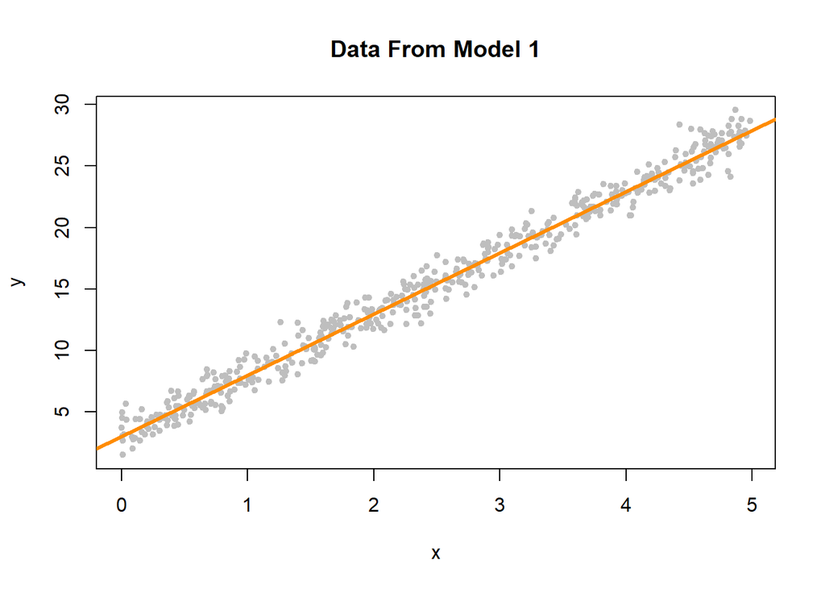

```r
plot(y~x, data=sim_data_1, col="grey", pch=20, main= "Data From Model 1")
fit_1 = lm(y~x, data=sim_data_1)
abline(fit_1, col= "darkorange", lwd=3)
```

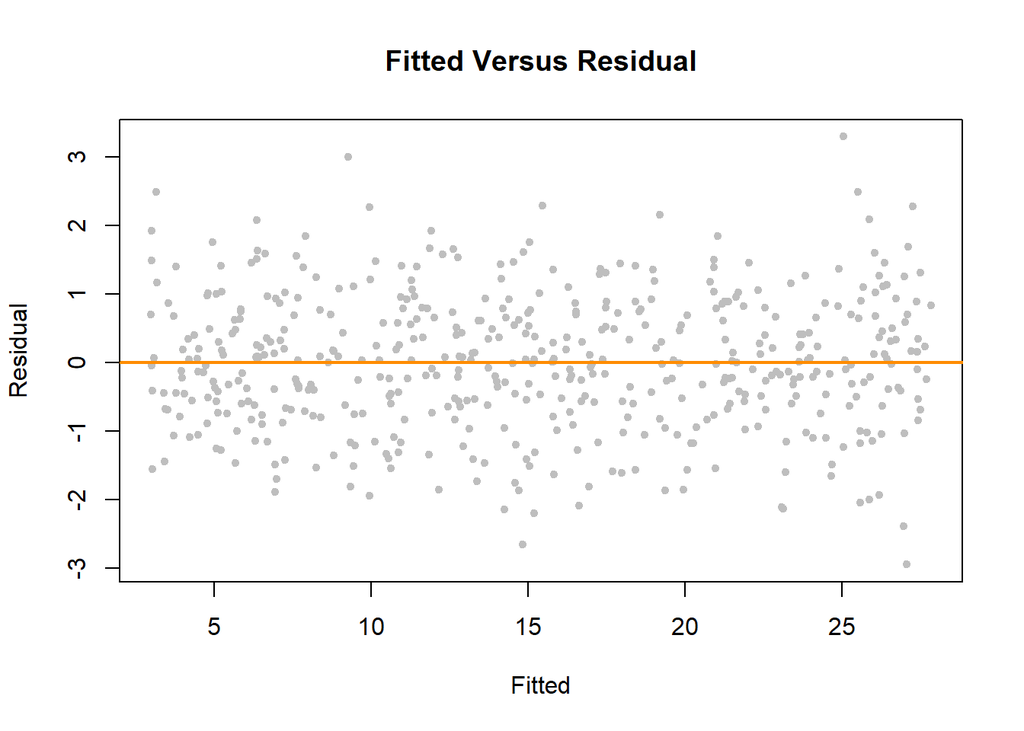

```r
plot(fitted(fit_1), resid(fit_1), pch=20, col="grey", main = "Fitted Versus Residual", xlab = "Fitted", ylab="Residual")
abline(h =0, col="darkorange", lwd=2)
```

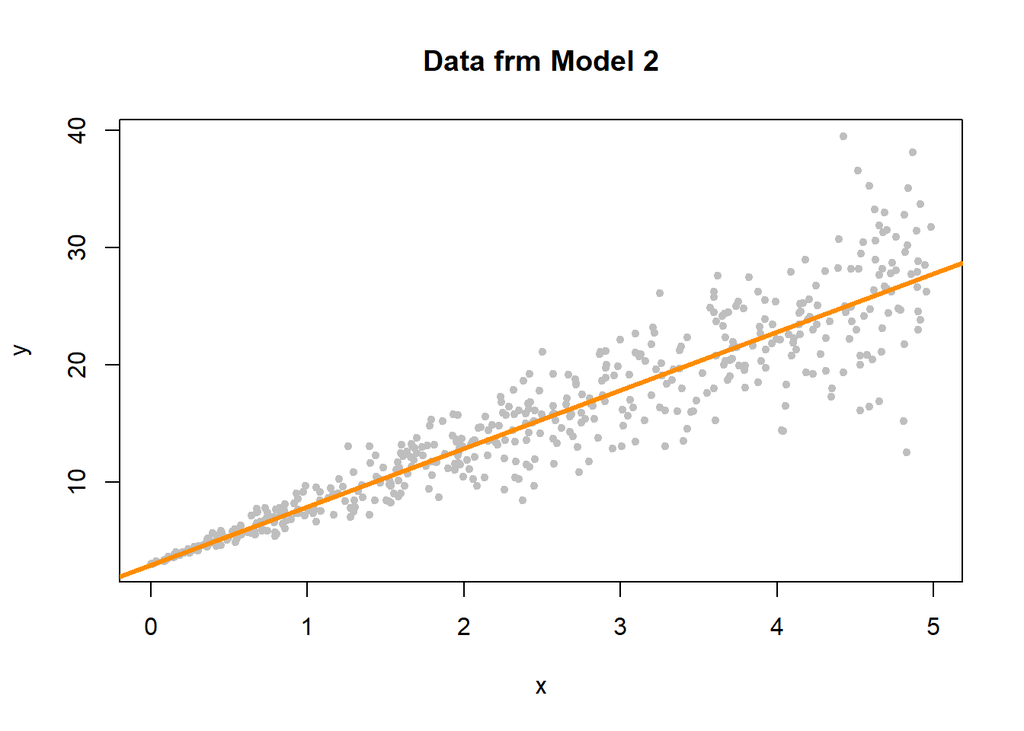

```r
set.seed(42)
sim_data_2 = sim_2()
fit_2 = lm(y~x, data = sim_data_2)
plot(y ~ x, data= sim_data_2, col="grey", pch=20, main = "Data frm Model 2")
abline(fit_2, col="darkorange", lwd=3)
```

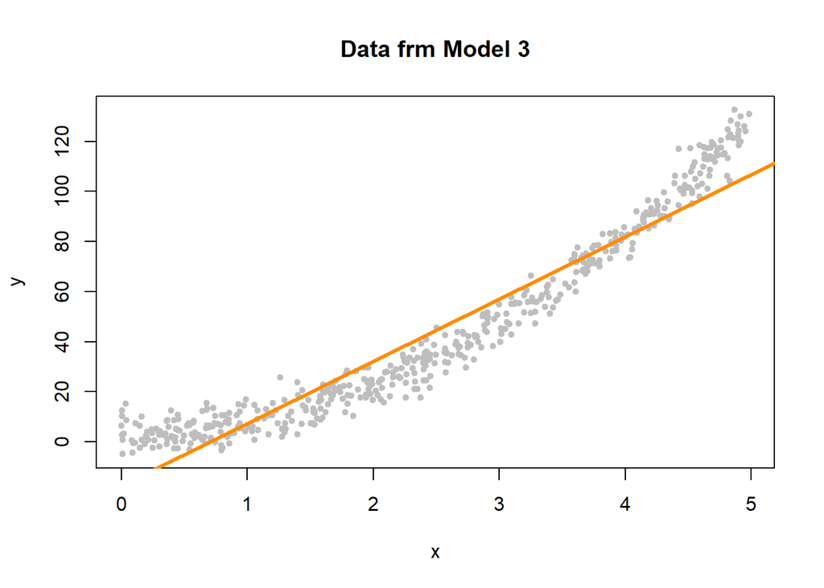

```r
set.seed(42)
sim_data_3 = sim_3()
fit_3 = lm(y~x, data = sim_data_3)
plot(y ~ x, data= sim_data_3, col="grey", pch=20, main = "Data frm Model 3")
abline(fit_3, col="darkorange", lwd=3)
```

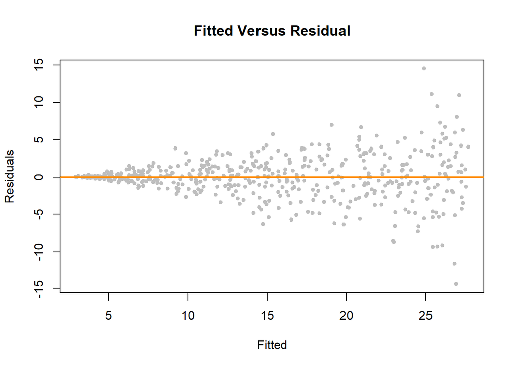

```r
plot(fitted(fit_2), resid(fit_2), col="grey", pch=20, xlab ="Fitted", ylab="Residuals", main = "Fitted Versus Residual")
abline(h=0, col="darkorange", lwd=2)
```

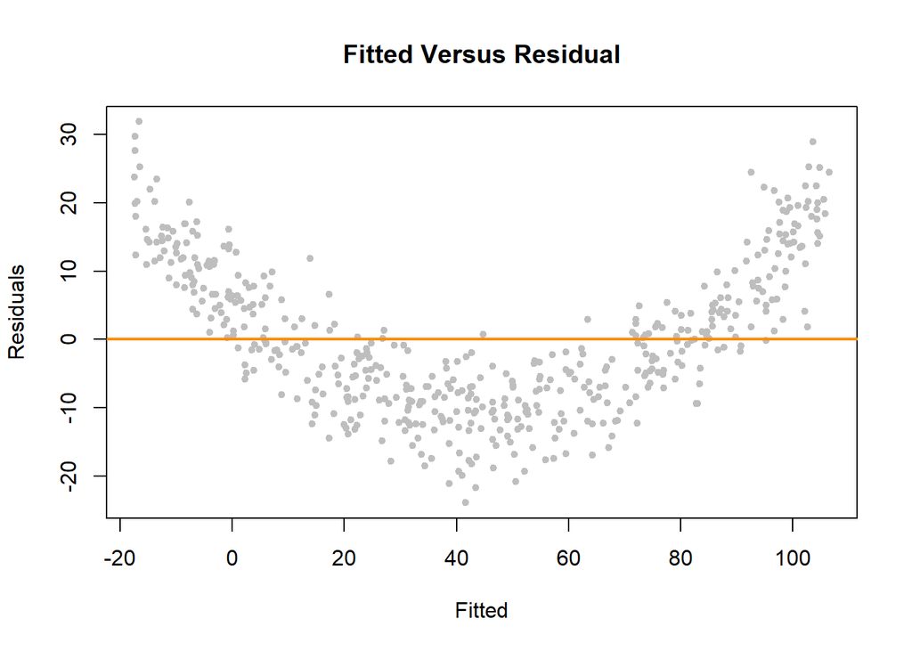

```r
plot(fitted(fit_3), resid(fit_3), col="grey", pch=20, xlab ="Fitted", ylab="Residuals", main = "Fitted Versus Residual")
abline(h=0, col="darkorange", lwd=2)
```

Model 2: Constant variance assumption is violated Model 3: Linearity assumption is violated

## 2.2 Breusch-Pagan Test

H0: Homoscedasticity. The errors have constant variance about the true model.  
H1: Heteroscedasticity. The errors have non-constant variance about the true model.

```r
library(lmtest)
bptest(fit_1)
```

```
##
##  studentized Breusch-Pagan test
##
## data:  fit_1
## BP = 1.0234, df = 1, p-value = 0.3117
```

```r
bptest(fit_2)
```

```
##
##  studentized Breusch-Pagan test
##
## data:  fit_2
## BP = 76.693, df = 1, p-value < 2.2e-16
```

```r
bptest(fit_3)
```

```
##
##  studentized Breusch-Pagan test
##
## data:  fit_3
## BP = 0.33466, df = 1, p-value = 0.5629
```

## 2.3 Historgram

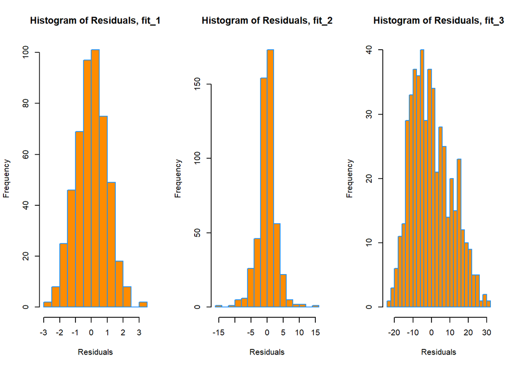

```r
par(mfrow = c(1, 3))
hist(resid(fit_1),
     xlab   = "Residuals",
     main   = "Histogram of Residuals, fit_1",
     col    = "darkorange",
     border = "dodgerblue",
     breaks = 20)
hist(resid(fit_2),
     xlab   = "Residuals",
     main   = "Histogram of Residuals, fit_2",
     col    = "darkorange",
     border = "dodgerblue",
     breaks = 20)
hist(resid(fit_3),
     xlab   = "Residuals",
     main   = "Histogram of Residuals, fit_3",
     col    = "darkorange",
     border = "dodgerblue",
     breaks = 20)
```

## 2.4 Q-Q Plots Normal Quantile-Quantile plot

```r
# qqnorm() plots the points
qqnorm(resid(fit_1), main = "Normal Q-Q Plot, fit_1", col = "darkgrey")
# qqline adds the necessary line
qqline(resid(fit_1), col = "dodgerblue", lwd = 2)
```

[output not shown]

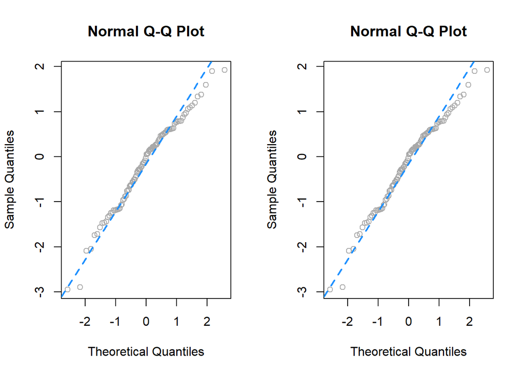

```r
qq_plot = function(e){
  n = length(e)
  normal_quantiles = qnorm(((1:n-0.5)/n))

  # plot theoretical versus observed quantiles
  plot(normal_quantiles, sort(e),
       xlab = c("Theoretical Quantiles"),
       ylab = c("Sample Quantiles"),
       col = "darkgrey")
  title("Normal Q-Q Plot")

  # calculate line through the first and third quantiles
  slope = (quantile(e, 0.75) - quantile(e, 0.25)) / (qnorm(0.75)-qnorm(0.25))
  intercept = quantile(e, 0.25) - slope*qnorm(0.25)

  # add to existing plot
  abline(intercept, slope, lty=2, lwd=2, col="dodgerblue")
}

set.seed(420)
x = rnorm(100, mean = 0 , sd = 1)
par(mfrow = c(1, 2))
qqnorm(x, col = "darkgrey")
qqline(x, lty = 2, lwd = 2, col = "dodgerblue")
qq_plot(x)
```

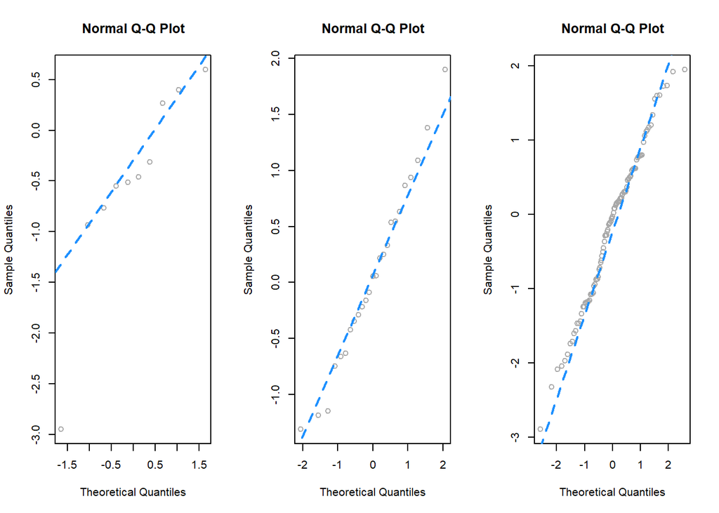

```r
par(mfrow = c(1, 3))
set.seed(420)
qq_plot(rnorm(10))
qq_plot(rnorm(25))
qq_plot(rnorm(100))
```

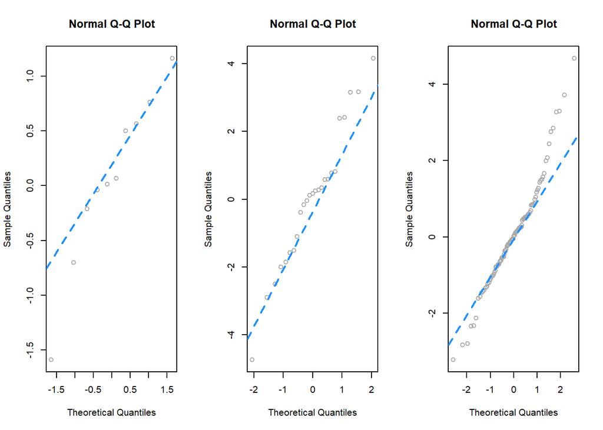

```r
par(mfrow = c(1, 3))
set.seed(420)
qq_plot(rt(10, df = 4))
qq_plot(rt(25, df = 4))
qq_plot(rt(100, df = 4))
```

```r
qqnorm(resid(fit_1), main = "Normal Q-Q Plot, fit_1", col = "darkgrey")
qqline(resid(fit_1), col = "dodgerblue", lwd = 2)
```

[output not shown]

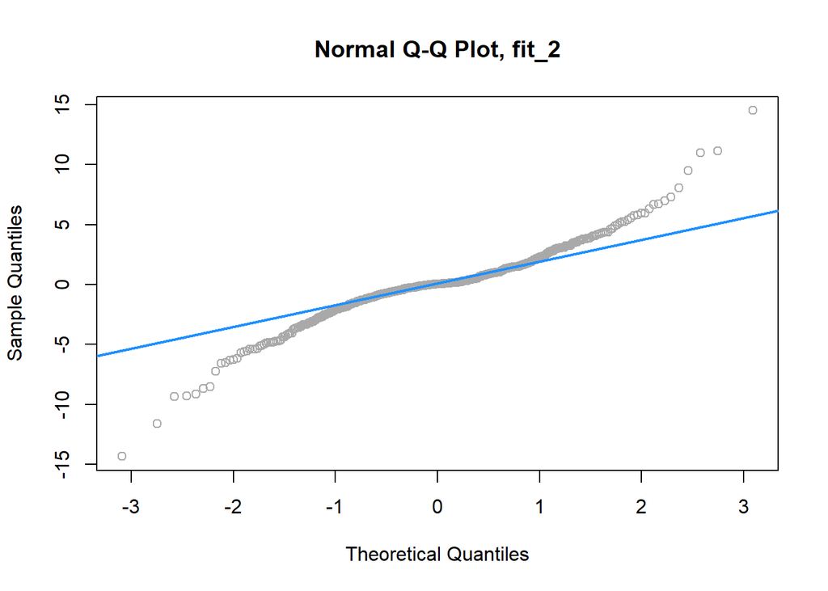

```r
qqnorm(resid(fit_2), main = "Normal Q-Q Plot, fit_2", col = "darkgrey")
qqline(resid(fit_2), col = "dodgerblue", lwd = 2)
```

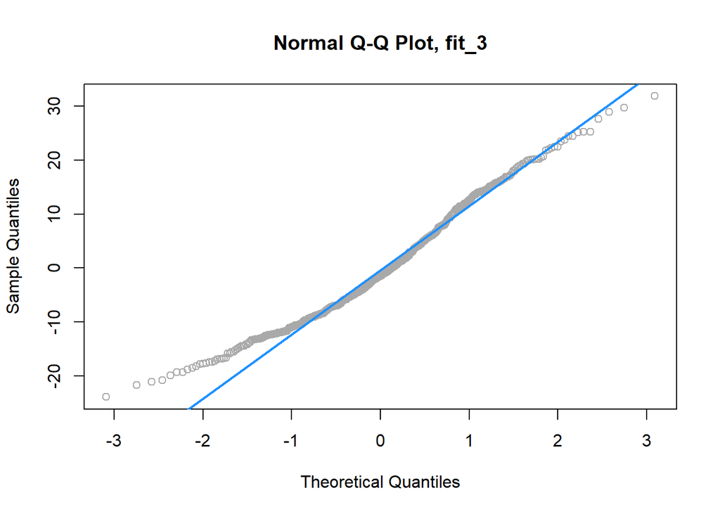

```r
qqnorm(resid(fit_3), main = "Normal Q-Q Plot, fit_3", col = "darkgrey")
qqline(resid(fit_3), col = "dodgerblue", lwd = 2)
```

## 2.5 Shapiro-Wilk Test

```r
set.seed(42)
shapiro.test(rnorm(25))
```

```
##
##  Shapiro-Wilk normality test
##
## data:  rnorm(25)
## W = 0.9499, p-value = 0.2495
```

```r
shapiro.test(rexp(25))
```

```
##
##  Shapiro-Wilk normality test
##
## data:  rexp(25)
## W = 0.71164, p-value = 1.05e-05
```

```r
shapiro.test(resid(fit_1))
```

```
##
##  Shapiro-Wilk normality test
##
## data:  resid(fit_1)
## W = 0.99858, p-value = 0.9622
```

```r
shapiro.test(resid(fit_2))
```

```
##
##  Shapiro-Wilk normality test
##
## data:  resid(fit_2)
## W = 0.93697, p-value = 1.056e-13
```

```r
shapiro.test(resid(fit_3))
```

```
##
##  Shapiro-Wilk normality test
##
## data:  resid(fit_3)
## W = 0.97643, p-value = 3.231e-07
```

# 3. Unsusual Observations

```r
par(mforw= c(1,3))
```

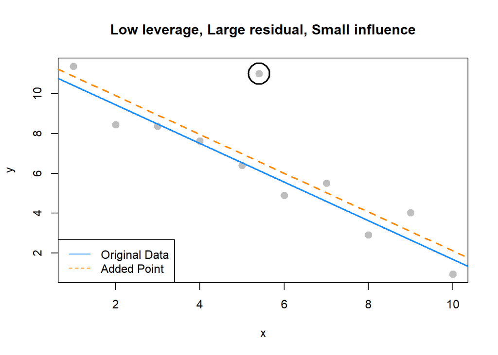

```r
set.seed(42)
ex_data = data.frame(x=1:10, y = 10:1 + rnorm(n=10))
ex_model = lm(y~x, data= ex_data)

# Low leverage, large residual, small influence
point_1 = c(5.4, 11)
ex_data_1 = rbind(ex_data, point_1)
model_1 = lm(y ~ x, data = ex_data_1)
plot(y~x, data= ex_data_1, cex= 2, pch = 20, col="grey", main="Low leverage, Large residual, Small influence")
points(x=point_1[1], y=point_1[2], pch=1, cex=4, col="black", lwd=2)
abline(ex_model, col="dodgerblue", lwd=2)
abline(model_1, lty = 2, col="darkorange", lwd=2)
legend("bottomleft", c("Original Data", "Added Point"), lty=c(1,2), col=c("dodgerblue", "darkorange"))
```

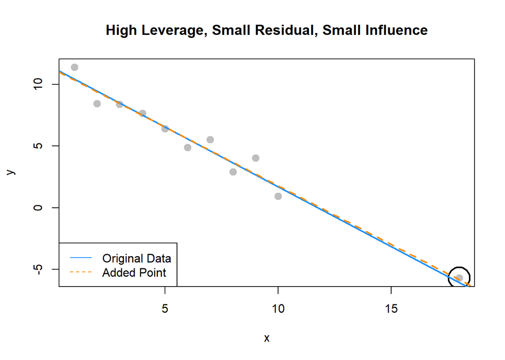

```r
# high leverage, small residual, small influence
point_2 = c(18, -5.7)
ex_data_2 = rbind(ex_data, point_2)
model_2 = lm(y ~ x, data = ex_data_2)
plot(y ~ x, data = ex_data_2, cex = 2, pch = 20, col = "grey",
     main = "High Leverage, Small Residual, Small Influence")
points(x = point_2[1], y = point_2[2], pch = 1, cex = 4, col = "black", lwd = 2)
abline(ex_model, col = "dodgerblue", lwd = 2)
abline(model_2, lty = 2, col = "darkorange", lwd = 2)
legend("bottomleft", c("Original Data", "Added Point"),
       lty = c(1, 2), col = c("dodgerblue", "darkorange"))
```

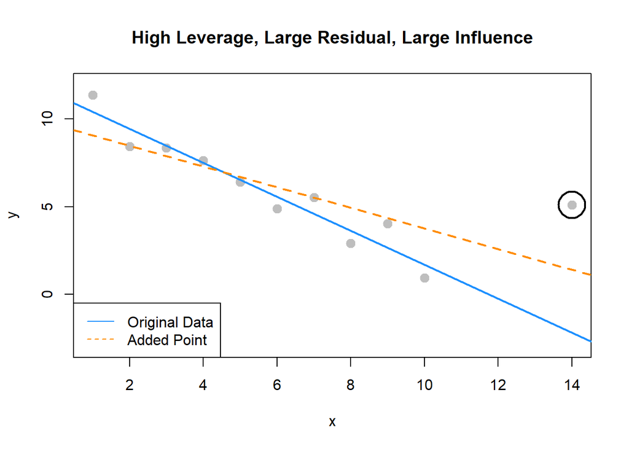

```r
# high leverage, large residual, large influence
point_3 = c(14, 5.1)
ex_data_3 = rbind(ex_data, point_3)
model_3 = lm(y ~ x, data = ex_data_3)
plot(y ~ x, data = ex_data_3, cex = 2, pch = 20, col = "grey", ylim = c(-3, 12),
     main = "High Leverage, Large Residual, Large Influence")
points(x = point_3[1], y = point_3[2], pch = 1, cex = 4, col = "black", lwd = 2)
abline(ex_model, col = "dodgerblue", lwd = 2)
abline(model_3, lty = 2, col = "darkorange", lwd = 2)
legend("bottomleft", c("Original Data", "Added Point"),
       lty = c(1, 2), col = c("dodgerblue", "darkorange"))
```

```r
coef(ex_model)[2]
```

```
##          x
## -0.9696033
```

```r
coef(model_1)[2]
```

```
##          x
## -0.9749534
```

```r
coef(model_2)[2]
```

```
##          x
## -0.9507397
```

```r
coef(model_3)[2]
```

```
##          x
## -0.5892241
```

## 3.1 Leverage

A data point with high leverage, is a data point that could have large influence when fitting the model.

$$\hat\beta = (X^TX)^{-1}X^Ty$$
$$\hat{y} = \hat\beta = X(X^TX)^{-1}X^Ty$$
$$H = X(X^TX)^{-1}X^T$$
Hat matrix is used to project onto the subspace spanned by the columns of X.
$$\hat y = Hy$$
The diagnoal elements of this matrix are called leverages
$$H_{ii} = h_{i}$$

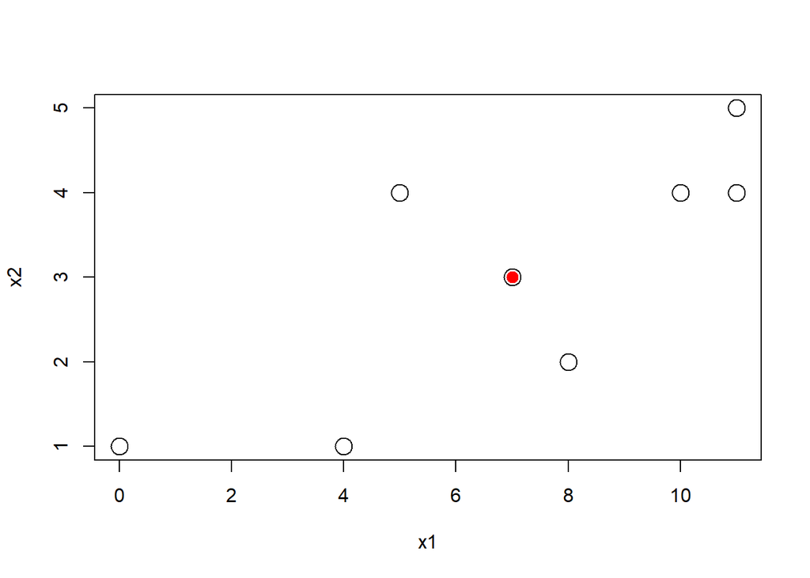

```r
lev_ex = data.frame(
  x1 = c(0, 11, 11, 7, 4, 10, 5, 8),
  x2 = c(1, 5, 4, 3, 1, 4, 4, 2),
  y = c(11, 15, 13, 14, 0, 19, 16, 8)
)
plot(x2 ~ x1, data=lev_ex, cex=2)
points(7,3, pch=20, col ="red", cex=2)
```

```r
X = cbind(rep(1,8), lev_ex$x1, lev_ex$x2)
H = X %*% solve(t(X)%*%X) %*% t(X)
diag(H)
```

```
## [1] 0.6000 0.3750 0.2875 0.1250 0.4000 0.2125 0.5875 0.4125
```

```r
sum(diag(H))
```

```
## [1] 3
```

```r
lev_fit = lm(y~., data = lev_ex)
hatvalues(lev_fit)
```

```
##      1      2      3      4      5      6      7      8
## 0.6000 0.3750 0.2875 0.1250 0.4000 0.2125 0.5875 0.4125
```

```r
coef(lev_fit)
```

```
## (Intercept)          x1          x2
##         3.7        -0.7         4.4
```

```r
lev_ex[which.max(hatvalues(lev_fit)),]
```

```
##   x1 x2  y
## 1  0  1 11
```

```r
lev_ex_1 = lev_ex
lev_ex_1$y[1] =20
lm(y~., data=lev_ex_1)
```

```
##
## Call:
## lm(formula = y ~ ., data = lev_ex_1)
##
## Coefficients:
## (Intercept)           x1           x2
##       8.875       -1.375        4.625
```

```r
lev_ex[which.min(hatvalues(lev_fit)),]
```

```
##   x1 x2  y
## 4  7  3 14
```

```r
lev_ex_2 = lev_ex
lev_ex_2$y[4] = 30
lm(y ~ ., data = lev_ex_2)
```

```
##
## Call:
## lm(formula = y ~ ., data = lev_ex_2)
##
## Coefficients:
## (Intercept)           x1           x2
##         5.7         -0.7          4.4
```

```r
hatvalues(model_1) > 2 * mean(hatvalues(model_1))
```

```
##     1     2     3     4     5     6     7     8     9    10    11
## FALSE FALSE FALSE FALSE FALSE FALSE FALSE FALSE FALSE FALSE FALSE
```

```r
hatvalues(model_2) > 2 * mean(hatvalues(model_2))
```

```
##     1     2     3     4     5     6     7     8     9    10    11
## FALSE FALSE FALSE FALSE FALSE FALSE FALSE FALSE FALSE FALSE  TRUE
```

```r
hatvalues(model_3) > 2 * mean(hatvalues(model_3))
```

```
##     1     2     3     4     5     6     7     8     9    10    11
## FALSE FALSE FALSE FALSE FALSE FALSE FALSE FALSE FALSE FALSE  TRUE
```

## 3.2 Outliers

Outliers are points which do not fit the model well.
$$e= y-\hat y = Iy - Hy = (I-H)y$$

$$Var(e_{i}) = (1-h_i)\sigma^2)$$
$$SE[e_i] = s_e\sqrt{(1-h_i)}$$
Standardized residual when n is large
$$r_i = \frac{e_i}{s_e\sqrt{1-h_i}} \sim N(\mu = 0, \sigma^2 = 1)$$

```r
resid(model_1)
```

```
##          1          2          3          4          5          6
##  0.4949887 -1.4657145 -0.5629345 -0.3182468 -0.5718877 -1.1073271
##          7          8          9         10         11
##  0.4852728 -1.1459548  0.9420814 -1.1641029  4.4138254
```

```r
rstandard(model_1)
```

```
##          1          2          3          4          5          6
##  0.3464701 -0.9585470 -0.3517802 -0.1933575 -0.3428264 -0.6638841
##          7          8          9         10         11
##  0.2949482 -0.7165857  0.6167268 -0.8160389  2.6418234
```

```r
rstandard(model_1)[abs(rstandard(model_1))>2]
```

```
##       11
## 2.641823
```

```r
rstandard(model_2)[abs(rstandard(model_2))>2]
```

```
## named numeric(0)
```

```r
rstandard(model_3)[abs(rstandard(model_3))>2]
```

```
##       11
## 2.704534
```

First plot has 11th point, the added point, with a large standardized residual. Second plot does not have one.  
The added point in plots two and three were both high leverage, but now only the point in plot three ahs a large residual.

## 3.3 Influence

Some outliers only change the regression a small amount(plot one) and some outliers have a large effect on the regression(plot three). Points with high leverage and large residual, we will call influential.
A common measure of influence is **Cook’s Distance**,
$$D_i = \frac{1}{p}r_i^2 \frac{h_i}{1-h_i}$$

Plot One: low leverage, large residual.  
Plot Two: high leverage, small residual.  
Plot Three: high leverage, large residual.

```r
n = length(resid(model_1))
cooks.distance(model_1)[11] > 4 /n
```

```
##    11
## FALSE
```

```r
cooks.distance(model_2)[11] > 4 /n
```

```
##    11
## FALSE
```

```r
cooks.distance(model_3)[11] > 4 /n
```

```
##   11
## TRUE
```

# 4. Data Analysis Examples